# Rethinking_week03_2019-04-15.Rmd

##### 3.3 sampling to simulate prediction

samples also can be used to simulate model; can help with model checks

###### 3.3.1 Dummy data

Dummy data: what model predicts you’d see at specific parameters

```r
rbinom( 1 , size=2 , prob=0.7 )
```

```
## [1] 1
```

code 3.23

```r
dummy_w <- rbinom( 1e5 , size=2 , prob=0.7 )
table(dummy_w)/1e5
```

```
## dummy_w
##       0       1       2
## 0.09082 0.41904 0.49014
```

code 3.24

```r
dummy_w <- rbinom( 1e5 , size=9 , prob=0.7 ) #100k samples
table(dummy_w)/1e5
```

```
## dummy_w
##       0       1       2       3       4       5       6       7       8
## 0.00003 0.00050 0.00418 0.02095 0.07309 0.17139 0.26776 0.26540 0.15677
##       9
## 0.03993
```

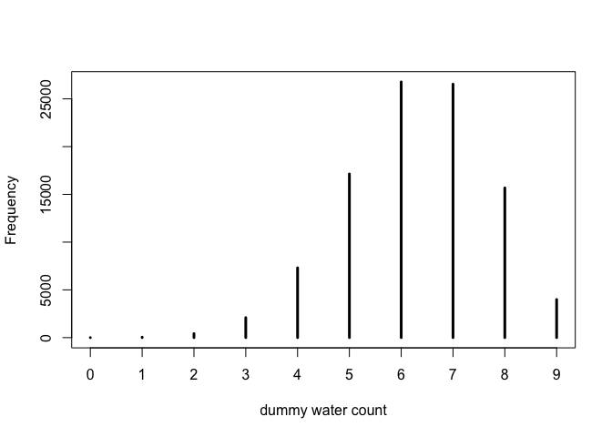

```r
simplehist( dummy_w , xlab="dummy water count" )
```

OK, what if my sample size is much bigger? I assume I’ll have tighter distribution

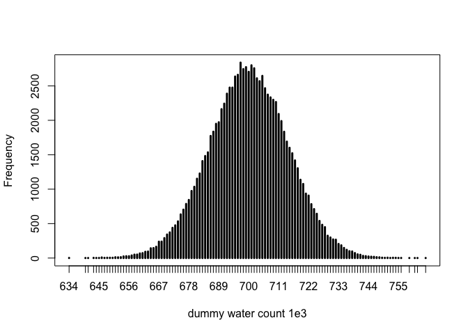

```r
dummy_test <- rbinom( 1e5 , size=1e3 , prob=0.7 ) #1000 samples
simplehist( dummy_test, xlab="dummy water count 1e3" )
```

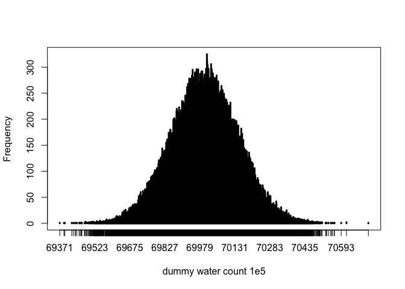

```r
# better
dummy_test <- rbinom( 1e5 , size=1e5 , prob=0.7 ) #100k samples
simplehist( dummy_test, xlab="dummy water count 1e5" )
```

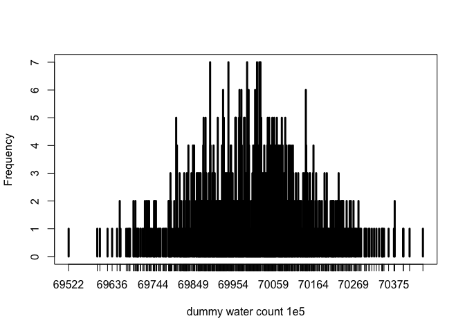

```r
# as above, but reduce number of pulls
dummy_test <- rbinom( 1e3 , size=1e5 , prob=0.7 ) #100k samples
simplehist( dummy_test, xlab="dummy water count 1e5" )
```

OK, this is just a way to simulate observations given a particular model.

###### 3.3.2 model checking

p. 64

‘retrodictions’ - make sure model produces samples that look like the data used to fit model.

want to comine sampling of simulated observations with sampling parameters from posterior distribution. (that is, use entire posterior, not just one point estimate derived from it)

Two ways model can be uncertain: first, even if probability is known for sure, you can’t determine what next outcome of trial will be with certainty.  
second, there is uncertainty about the true probability. the posterior distribution over p is this.

- posterior predictive distribution* is simply computation of sampling distribution of outcomes at every value of p. See Figure 3.6.

R code 3.25, 3.26

```r
w <- rbinom( 1e4 , size=9 , prob=0.6 )
table(w)
```

```
## w
##    0    1    2    3    4    5    6    7    8    9
##    4   37  198  741 1731 2545 2415 1628  603   98
```

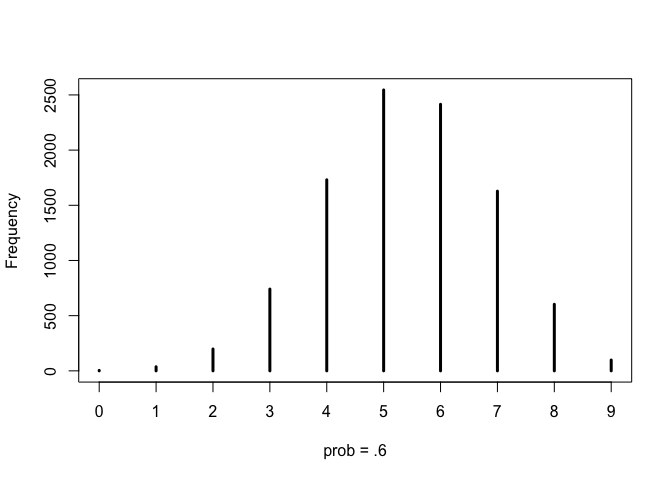

```r
simplehist( w , xlab="prob = .6" )
```

```r
# but now replace prob of .6 with **samples from the posterior**
w <- rbinom( 1e4 , size=9 , prob=samples )
table(w)
```

```
## w
##    0    1    2    3    4    5    6    7    8    9
##    7   50  134  318  508  810 1093 1643 2315 3122
```

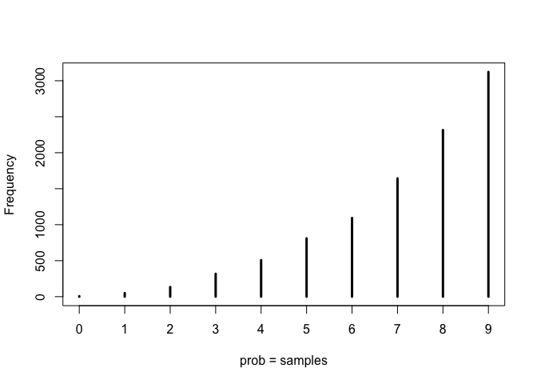

```r
simplehist( w , xlab="prob = samples" )
```

## Homework

3E1 - 3E7 ### Easy code 3.27

```r
p_grid <- seq( from=0 , to=1 , length.out=1000 )
prior <- rep( 1 , 1000 )
likelihood <- dbinom( 6 , size=9 , prob=p_grid )
posterior <- likelihood * prior
posterior <- posterior / sum(posterior)
set.seed(100)
samples <- sample( p_grid , prob=posterior , size=1e4 , replace=TRUE )
```

First, let’s look at samples

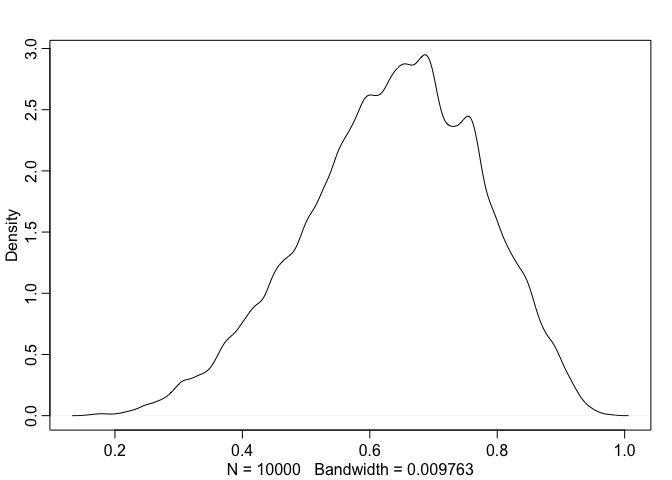

```r
library(rethinking)
dens( samples )
```

### 3E1. How much posterior probability lies below p = 0.2?

```r
sum( samples < 0.2 ) / 1e4
```

```
## [1] 5e-04
```

```r
# that is a small value: 5 e-4
```